# US Weather Impact Analysis

========================================================================================================================

## Synopsis

The U.S. National Oceanic and Atmospheric Administration’s (NOAA) [storm database](https://d396qusza40orc.cloudfront.net/repdata%2Fdata%2FStormData.csv.bz2) was used to compare outcomes from storm and severe weather event categories. The events in the database start in the year 1950 and end in November 2011. In the earlier years of the database there are generally fewer events recorded, most likely due to a lack of good records. More recent years should be considered more complete

Our basic goal is to explore the NOAA Storm Database and answer some basic questions about severe weather events.

## Data Analysis Outcome

The purpose of this analysis is to explore the given data and evaluate the below issues.

- Across the United States, which types of events (as indicated in the EVTYPE variable) are most harmful with respect to population health?
- Across the United States, which types of events have the greatest economic consequences?

========================================================================================================================

## Data Processing

### Load the required packages

```r
library(xtable)
library(knitr)
```

### Load the NOAA database

```r
setwd("/Users/mohana/Documents/Coursera/WDir")
rawfile <- "repdata-data-StormData.csv.bz2"

if (!file.exists(rawfile)) {
    download.file("https://d396qusza40orc.cloudfront.net/repdata%2Fdata%2FStormData.csv.bz2", rawfile, method="wget", extra="--no-check-certificate")
}
```

### Cleansing the data

The following fields were used for this analysis:

| **Field** | **Description** |
| --- | --- |
| BGN_DATE | Date the storm event began |
| EVTYPE | Type of storm event (not abbreviated) |
| FATALITIES | The number of deaths directly related to the weather event |
| INJURIES | The number of injuries directly related to the weather event |
| PROPDMG | The estimated amount of damage to property incurred by the weather event (whole numbers and hundredths) |
| PROPDMGEXP | A multiplier where “H” denotes hundreds, ’K” denotes thousands, “M” denotes millions, and “B” denotes billions |
| CROPDMG | The estimated amount of damage to crops incurred by the weather event (whole numbers and hundredths) |
| CROPDMGEXP | A multiplier where “H” denotes hundreds, ’K” denotes thousands, “M” denotes millions, and “B” denotes billions |

Code below implements:

1. Limit the date range to 1993 to 2011
2. Select the required fields
3. Adjust property multipliers
4. Adjust crop multipliers
5. Clean event type by trimming multiple spaces, leading and trailing spaces.

```r
datafile <- "repdata-data-StormData.csv"

if (!file.exists(datafile)) {
  rawdata <- read.csv(bzfile(rawfile), header = TRUE, stringsAsFactors = FALSE)

  rawdata$BGN_DATE <- as.Date(rawdata$BGN_DATE, format = "%m/%d/%Y %H:%M:%S")
  # 1. Limit Data Range
  data <- rawdata[rawdata$BGN_DATE >= as.Date("1993-01-01"), ]
  data <- data[data$INJURIES > 0 | data$FATALITIES > 0 | data$PROPDMG > 0 | data$CROPDMG > 0, ]
  # 2. Select the required Data fields
  data <- data[, c("BGN_DATE", "EVTYPE", "FATALITIES", "INJURIES", "PROPDMG", "PROPDMGEXP", "CROPDMG", "CROPDMGEXP")]
  # 3. Adjust PROPDMG multiplier
  data$PROPDMGEXP[is.na(data$PROPDMGEXP)] <- 0
  data$PROPDMGEXP[data$PROPDMGEXP == ""] <- 1
  data$PROPDMGEXP[grep("[-+?]", data$PROPDMGEXP)] <- 1
  data$PROPDMGEXP[grep("[Hh]", data$PROPDMGEXP)] <- 100
  data$PROPDMGEXP[grep("[Kk]", data$PROPDMGEXP)] <- 1000
  data$PROPDMGEXP[grep("[Mm]", data$PROPDMGEXP)] <- 1000000
  data$PROPDMGEXP[data$PROPDMGEXP == "B"] <- 1000000000
  data$PROPDMGEXP <- as.numeric(data$PROPDMGEXP)
  # 4. Adjust CROPDMG multiplier
  data$CROPDMGEXP[is.na(data$CROPDMGEXP)] <- 0
  data$CROPDMGEXP[data$CROPDMGEXP == ""] <- 1
  data$CROPDMGEXP[grep("[-+?]", data$CROPDMGEXP)] <- 1
  data$CROPDMGEXP[grep("[Hh]", data$CROPDMGEXP)] <- 100
  data$CROPDMGEXP[grep("[Kk]", data$CROPDMGEXP)] <- 1000
  data$CROPDMGEXP[grep("[Mm]", data$CROPDMGEXP)] <- 1000000
  data$CROPDMGEXP[data$CROPDMGEXP == "B"] <- 1000000000
  data$CROPDMGEXP <- as.numeric(data$CROPDMGEXP)

  data$PROPDMG <- data$PROPDMG * data$PROPDMGEXP
  data$CROPDMG <- data$CROPDMG * data$CROPDMGEXP

  # 5. Clean Event Type
  data$EVTYPE <- toupper(data$EVTYPE)

  trim <- function(x) gsub("[[:space:]]{2,}", " ", gsub("(^[[:space:]]+|[[:space:]]+$)", "", x))
  data$EVTYPE <- trim(data$EVTYPE)

  write.csv(data, file = datafile, row.names = FALSE)
} else {
  data <- read.csv(datafile, header = TRUE, stringsAsFactors = FALSE)
}
```

========================================================================================================================

## Results

### Population Health

```r
populationdata <- data[, c("EVTYPE", "INJURIES", "FATALITIES")]
populationdata <- aggregate.data.frame(x = populationdata[,
    c(2, 3)], by = list(populationdata$EVTYPE), FUN = sum)
colnames(populationdata)[1] <- "EVTYPE"
populationdata$TOTAL <- populationdata$FATALITIES + populationdata$INJURIES
populationdata <- populationdata[order(populationdata$TOTAL,
    decreasing = TRUE), ]
row.names(populationdata) <- populationdata$EVTYPE
populationdata <- populationdata[populationdata$TOTAL != 0, ]
```

### Table Representation

We will be represting this data through a sorted table

```r
populationdata <- xtable(populationdata[1:10, c("INJURIES",
    "FATALITIES")], caption = "Table 1. Event types that accounted for the highest cumulative injuries and fatalities")
names(populationdata) <- c("Injuries", "Fatalities")
kable(populationdata, format="markdown")
```

[output not shown]

### Plot Generation

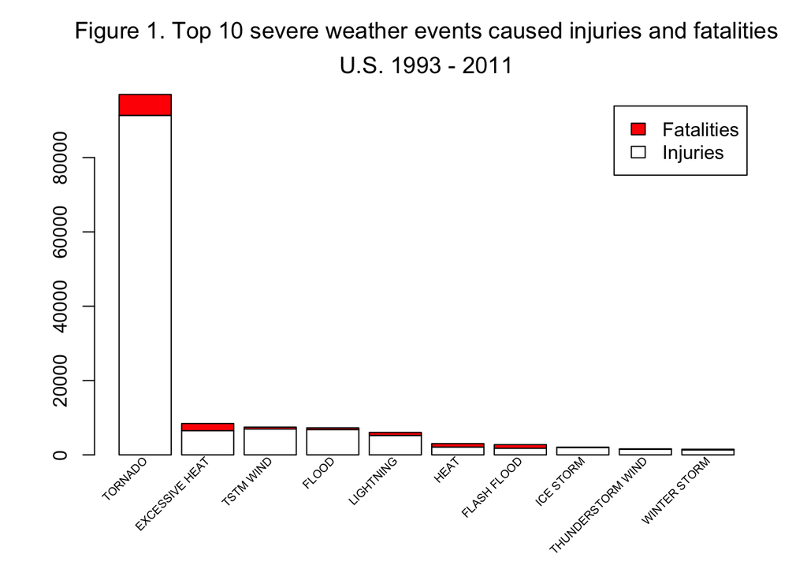

```r
populationplot <- barplot(height = t(as.matrix(populationdata[1:10,
    c("Injuries", "Fatalities")])), main = bquote(atop("Figure 1. Top 10 severe weather events caused injuries and fatalities",
    "U.S. 1993 - 2011")), legend = c("Injuries", "Fatalities"), axes = FALSE,
    axisnames = FALSE, col = c("white", "red"))

text(populationplot, par("usr")[3], labels = row.names(populationdata)[1:10],
    srt = 45, adj = 1, cex = 0.6, xpd = TRUE)
axis(2)
```

The figure above illustrates the impact of extreme weather events are higher in tornado event.

## Economy Consequences

```r
economydata <- data[, c("EVTYPE", "PROPDMG", "CROPDMG")]
economydata <- aggregate.data.frame(x = economydata[, c(2, 3)], by = list(economydata$EVTYPE),
    FUN = sum)
colnames(economydata)[1] <- "EVTYPE"
economydata$TOTAL <- economydata$PROPDMG + economydata$CROPDMG
economydata <- economydata[order(economydata$TOTAL, decreasing = TRUE), ]
row.names(economydata) <- economydata$EVTYPE
economydata <- economydata[economydata$TOTAL != 0, ]
```

### Table Representation

We will be represting this data through a sorted table

```r
economytable <- xtable(economydata[1:10, c("PROPDMG", "CROPDMG")], caption = "Table 2. Event types that accounted for the highest property damage and crop damage")
names(economytable) <- c("Property Damage", "Crop Damage")
kable(economytable, format="markdown")
```

[output not shown]

### Plot Generation

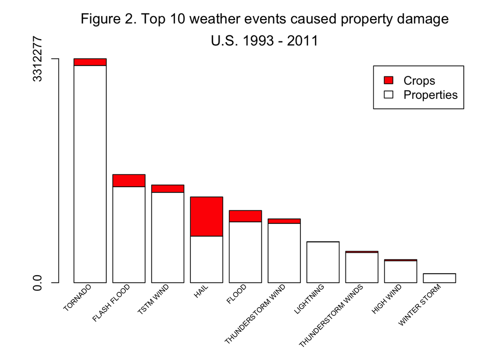

```r
economyplot <- barplot(height = t(as.matrix(economydata[1:10, c("PROPDMG",
    "CROPDMG")])), main = bquote(atop("Figure 2. Top 10 weather events caused property damage",
    "U.S. 1993 - 2011")), legend = c("Properties", "Crops"), axes = FALSE, axisnames = FALSE,
    col = c("white", "red"))

text(economyplot, par("usr")[3], labels = row.names(economydata)[1:10], srt = 45,
    adj = 1, cex = 0.6, xpd = TRUE)

axis(2, at = c(0, economydata[1, "TOTAL"]), labels = c("0.0", format(economydata[1,
    "TOTAL"], digits = 2)))
```

The figure above depicts the impact of weather events that are severe on economy.